# ACS AWS Training

### Nathan Miles

06/01/2020

## Day 1 Outline

- What the heck even is AWS?
- AWS Infrastrucutre
- Interacting with AWS
- Overview of a few AWS services
  - Identity Access Management, IAM
  - Simple Storage Service, S3
  - Elastic Compute Cloud, EC2
  - Lambda
- Getting setup
  - Configuring the AWS credentials file
- Working with the console
- Setting up ssh keys

## First things first

[figure not shown]

## Web Applications and Web APIs

- Web Applications use browser-based interface
- Web APIs use programmatic interface

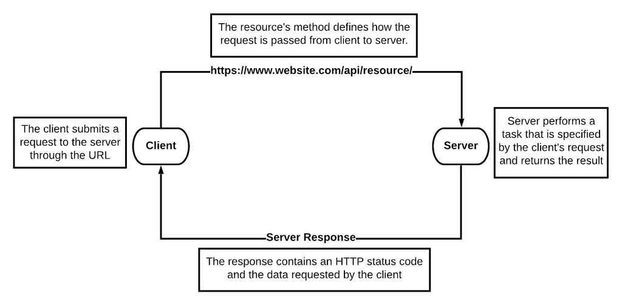

## AWS Infrastructure

- AWS operates across the world in distinct areas called AWS Regions
- AWS Regions are clusters of data centers
- A group of data centers within an AWS Region is called an Availability Zone (AZ)

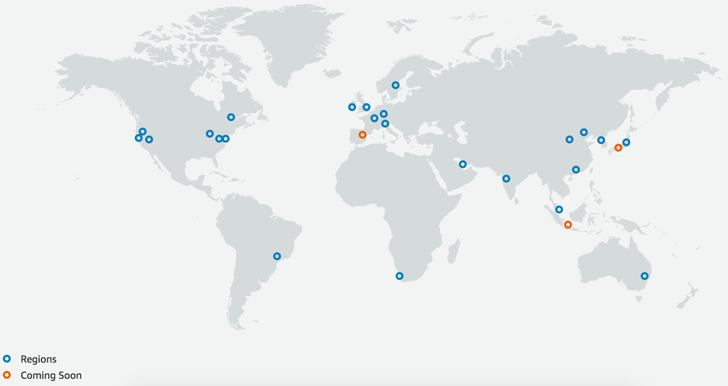

## Interacting with AWS

- The AWS Management Console
  - Web application
  - Provides browser-based access to all AWS services
- The AWS CLI
  - Web API
  - Provides programmatic access to all AWS services
  - Install via pip
    - `pip install awscli`
- `Boto3`
  - AWS Software Development Kit (SDK) for Python
  - Provides the programmatic access to AWS via python

## IAM

- Web service designed to manage access to AWS services
- Authentication
  - Who do we allow to have access to AWS?
  - IAM User
- Permissions
  - What services do we allow them to use?
  - IAM Policies

## IAM

- IAM User
  - An individual account that is associated with one person
  - Each account has a set of policies attached that control the person's ability to utilize services on AWS
  - Access keys are used to authenticate the IAM user when using the programmatic interface
- IAM Group
  - A collection of IAM Users who all require the same permissions
  - IAM Users can belong to multiple IAM Groups
- IAM Role
  - The same concept as an IAM User
  - Each IAM Role has a unqiue set of policies attached that control the role's ability to utilize services on AWS
  - Trusted entities (IAM Users) can *assume* IAM Roles

## S3

- Web service designed to provide people with ability to store virtually any amount of data in the cloud
- Terminology
  - S3 **bucket** is the location where the data is stored
  - S3 **object** is the data itself
- Several large datasets are already being hosted in the cloud to facilitate data analysis
  - [AWS Public Datasets](https://registry.opendata.aws/)
  - The entire public dataset for HST is currently available on AWS
  - The S3 bucket lives in the AWS Region `us-east-1` (N. Virginia)
- S3 bucket mimics the structure of a directory
  - bucket_name/directory1/data
  - bucket_name/directory2/subdirectory1/data

## S3

- Access can be granted on a per-user basis
  - Keep the results within the collaboration!
- Can even host static websites
  - Code documentation
  - Personal website

## S3 Pricing

- Pay for the amount of data stored in the bucket on a monthly basis
- Pay for any requests submitted to your bucket
- Pay for the amount of data retrieved
- Pay for the bandwidth used in all data transfers **out of S3** via the internet
  - Free to transfer from S3 to EC2 (and vice-versa) if they are in the same region
- Always free to transfer data in

## EC2

- Web service designed to provide people with the ability to deploy servers in the cloud
  - Servers are referred to as "instances" in AWS lingo
- The operating system is specified by Amazon Machine Images (AMI)
  - Numerous preconfigured ones (Linux, Ubuntu
  - Can also create your own that has all your favorite software installed
    - e.g. astroconda
- Variety of instance types
  - General purpose
  - Compute optimized
  - Memory optimized
  - Accelerated computing
  - Storage optimized

#### [EC2 Pricing Details](https://aws.amazon.com/ec2/pricing/)

## EC2

- EC2 instances are accessed via `ssh`
  - `ssh` access is controlled through Security Groups
  - Server can be available to the public
    - Anyone with the public `ssh` key can then log in to the server
  - Can also restrict `ssh` access to only your IP
- For commonly used instances, you can define launch templates
  - instance type, storage, security groups, key/pair name
- All data transfers are free between S3 buckets and EC2 instances when they are in the same region

## EC2 Pricing

- Pay for the compute resources used
  - Billed in 1 second increments with a minimum of 60s
- Pay for any data transfers from EC2 to the internet or across regions.
  - Same fees apply as those for S3 transfer rates
- Pay for the Elastic Block Storage (EBS) volume used
  - An EBS volume is essentially extra disk space for your server

## EC2 Pricing Example

- Instance type: c5.9xlarge
  - Compute optimized
  - 36 cores, 72 GB of RAM
  - Cost: \$1.53 per hour
- EBS volume: 100 GB
  - Cost: \$0.1/(GB-month) -> \\$0.00013/(GB-hr)
- The computation takes 4 hours to complete
  - Instance cost: \$1.53/hr * 4 hr = \\$6.12
  - EBS cost: \$0.00013/(GB-hr) * (100 GB * 4hr) = \\$0.05
- Total cost: \$6.17

## EC2 Pricing by Instance

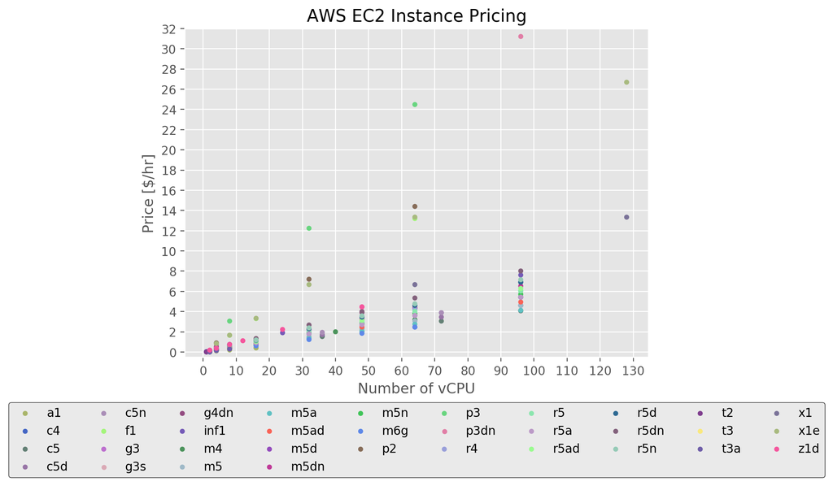

## EC2 Pricing By Instance Type

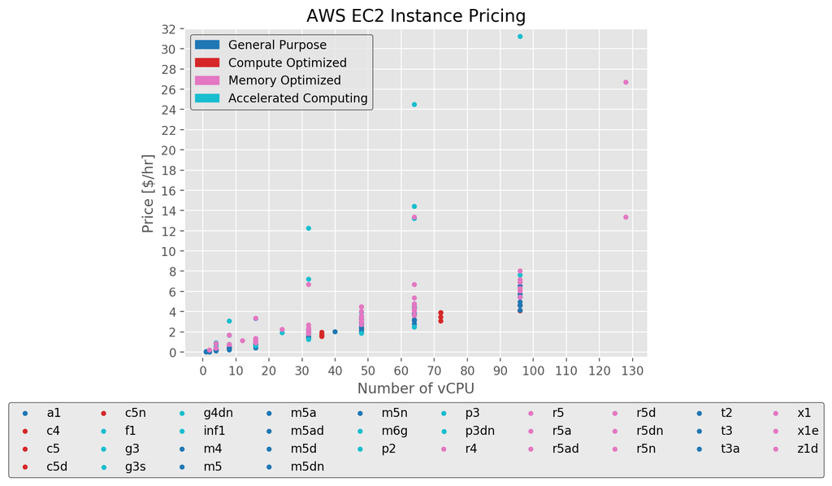